# Juvenile snowshoe hares in Bonanza Creek Experimental Forest LTER

#### Comparison of male and female juvenile hare weights across study sites

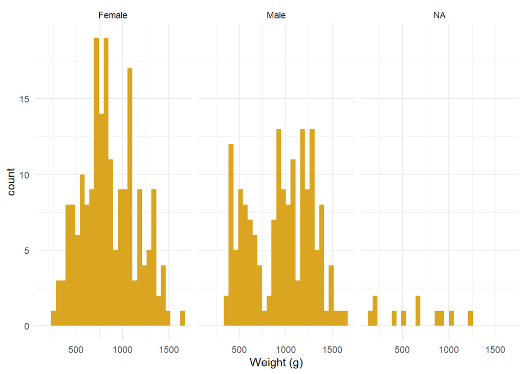

**Figure 2.** Histogram depicting the distribution of weights of all male and female juvenile snowshoe hares. Weights of hares captured in live-traps were measured in grams for male, female, and unsexed hares. Individuals with no sex recorded at time of weighing are shown in the plot labelled 'NA'. Data: Kielland et al. (2017).

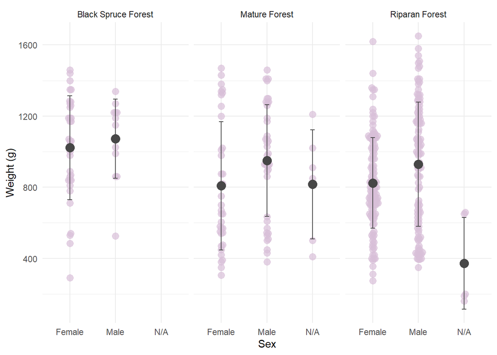

**Figure 3. Juvenile showshoe hares weights at three different sites witin the Bonanza Creek Experimental Forest.** Weights of hares captured in live-traps were measured in grams for male, female, and unsexed hares. Points indicate individual observations, mean is indicated by the black point, and error bars indicate the standard deviation from the mean. Data: Kielland et al. (2017).

**Table 2.** Descriptive statistics (mean, median, standard deviation, and sample size) for juvenile snowshoe hares at three sampling sites in Bonanza Creek Experimental Forest. Data: Kielland et al. (2017).

[output not shown]